# STSCI 4630 - Spring 2019 - HW8

Da (Harry) Lu, dl947

Due Thursday, Apr/18/2019

# Question 1

[24 points] Run lines 1 to 9 to define the function `BS_price_sim()`, and run lines 10 to 16 to define `BS_price_formula`. Adapt and run lines 17 to 24 for the case where the stock has initial price $S_0=80$ at time $t=0$ with annual drift $\mu=0.055$ and volatility $\sigma=0.2$; the call option has strike price $K=75$ and lifetime $T=1.25$ years; and the continuously compounded risk-free rate is $r=0.03$. Use the sample size $10,000,000$, set the seed equal to $4630$ for random number generation, and use confidence level $90\%$ for the confidence intervals. Submit the output.

```r
a=BS_price_sim(S_0=80,sigma=0.2,K=75,T=1.25,r=0.03,n_sim=10000000,seed=4630)
#a[1]
#a[2]
interval=a[1]+c(-1,1)*qnorm(0.95)*a[2]/sqrt(a[3])
#interval[1]
#interval[2]
b=BS_price_formula(S_0=80,sigma=0.2,K=75,T=1.25,r=0.03)
#b
difference=a[1]-b
#difference
difference_interval=difference+c(-1,1)*qnorm(0.95)*a[2]/sqrt(a[3])
#difference_interval[1]
#difference_interval[2]
```

i) Report the simulation-based estimate of the discounted risk-neutral expectation of the value of the call option at expiration.

The expectation is 11.3469935.

ii) Report the simulation-based estimate of the standard deviation of the discounted riskneutral value of the call option at expiration.

The standard deviation is 14.349522.

iii) Report the simulation-based $90\%$ confidence interval for the discounted risk-neutral expectation of the value of the call option at expiration.

The considence interval is (11.3395296, 11.3544574).

iv) Report the price of the call option derived from the Black-Scholes formula.

The price is 11.3463548.

v) Report the simulation-based estimate of the difference between the discounted riskneutral expectation of the value of the call option at expiration and the price of the call option as derived from the Black-Scholes formula.

The difference is 0.0006387.

vi) Report the simulation-based $90\%$ confidence interval for the difference between the discounted risk-neutral expectation of the value of the call option at expiration and the price of the call option as derived from the Black-Scholes formula. Does the confidence interval provide evidence against the veracity of the Black-Scholes formula? Justify your answer briefly.

The confidence interval is (-0.0068251, 0.0081026).

No, the confidence interval contains $0$.

vii) Calculate the price of a European put option, written at the same time as the call option, having strike price $K=75$ and lifetime $T=1.25$ years.

$$\textbf{C}+e^{−rT}K=\textbf{P}+S_0$$

```r
11.3463548+exp(-0.03*1.25)*75-80
```

```
## [1] 3.585936
```

$$\begin{align}
\textbf{P}
&=\textbf{C}+e^{−rT}K-S_0\\
&=11.3463548+e^{-0.03\times1.25}\times75-80\\
&\approx3.585936
\end{align}$$

# Question 2

[22 points] Run lines 25 to 31 to define the function `BS_price_t_sim()`. Adapt and run lines 32 to 42 to study the price of a call option having strike price $K=75$ and expiry date $T=1.25$ years. The underlying stock has initial price $S_0=80$ at time $t=0$ when the option is written; the stock is assumed to have drift $\mu=0.055$ per year and volatility $\sigma=0.2$ per year; and the continuously compounded risk-free rate is $r=0.03$ per year. Use the sample size $10,000,000$, and set the seed equal to $4630$ for random number generation. Suppose that an investor decides to buy the option at time $t=0$, and she plans to sell the option at time $t=0.75$ year.

```r
C=BS_price_formula(S_0=80,sigma=0.2,K=75,T=1.25,r=0.03)
#C
C_t=BS_price_t_sim(t=0.75,S_0=80,mu=0.055,sigma=0.2,K=75,T=1.25,r=0.03,n_sim=10000000,seed=4630)
#par(lwd=2);par(cex=2)
#hist(C_t/C)
#hist(log(C_t/C))
#par(lwd=1);par(cex=1)
#mean(C_t/C);sd(C_t/C)
#mean(log(C_t/C));sd(log(C_t/C))
ind=as.numeric(C_t<=C)
#mean(ind)
```

i) Report the price of the call option when the option is written.

The price of the call option is 11.3463548.

ii) Submit the histogram of the simulated gross returns for the investor’s strategy.

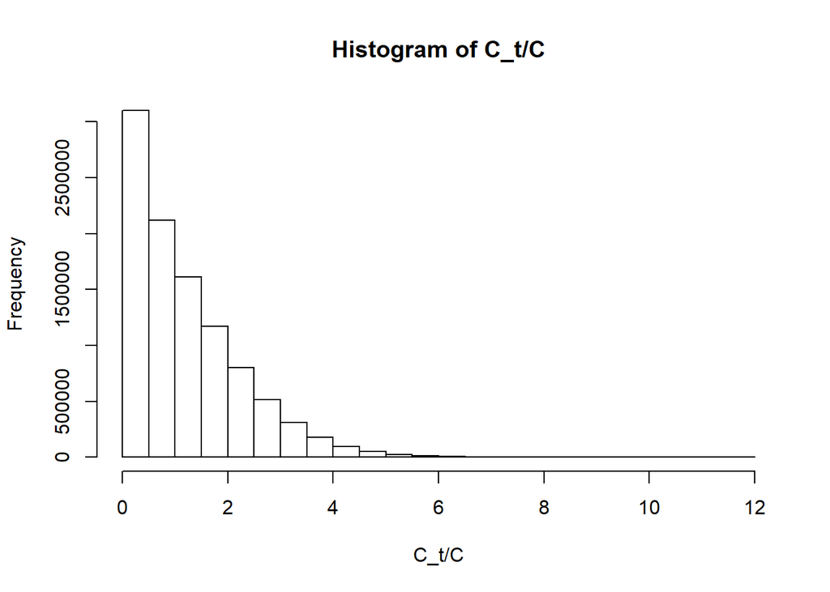

iii) Submit the histogram of the simulated log gross returns for the investor’s strategy.

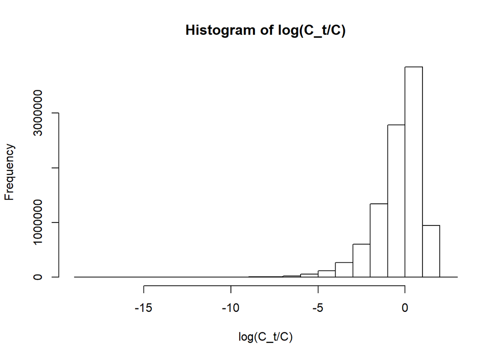

iv) Report the simulation-based estimate of the expected gross return for the investor’s strategy.

The expected gross return is 1.2059042.

v) Report the simulation-based estimate of the standard deviation of the gross return for the investor’s strategy.

The standard deviation of the gross return is 1.0442387.

vi) Report the simulation-based estimate of the expected log gross return for the investor’s strategy.

The expected log gross return is -0.367839.

vii) Report the simulation-based estimate of the standard deviation of the log gross return for the investor’s strategy.

The standard deviation of the log gross return is 1.349826.

# Question 3

[15 points] Adapt and run lines 43 to 57 to study the price of a call option having strike price $K=75$ and expiry date $T=1.25$ years. The underlying stock has initial price $S_0=80$ at time $t=0$ when the option is written; the stock is assumed to have drift $\mu=0.055$ per year and volatility $\sigma=0.2$ per year; and the continuously compounded risk-free rate is $r=0.03$ per year. Use the sample size $10,000,000$, and set the seed equal to $4630$ for the random number generation. Consider the difference $C_t-(S_t-K)_+$ for $t=0.75$, where $C_t$ is the price of the option at time $t$ and $(S_t-K)_+$ is the exercise value of the option at time $t$.

```r
diff_t=compare_t_sim(t=0.75,S_0=80,mu=0.055,sigma=0.2,K=75,T=1.25,r=0.03,n_sim=10000000,seed=4630)
#par(lwd=2);par(cex=2)
#hist(diff_t)
#mean(diff_t)
#sd(diff_t)
#min(diff_t)
```

i) Submit the histogram of the simulated differences $C_t-(S_t-K)_+$ for $t=0.75$.

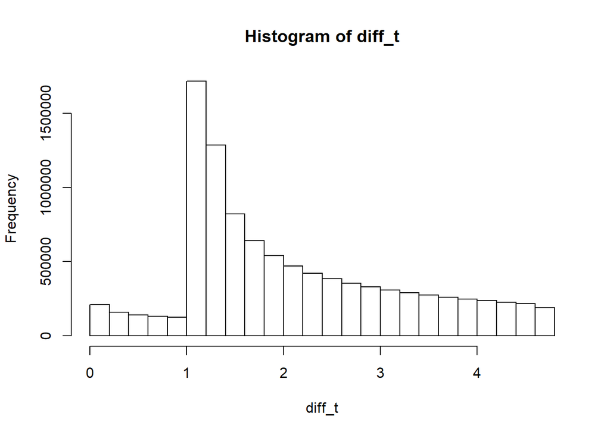

ii) Report the simulation-based estimate of the expectation of the difference $C_t-(S_t-K)_+$ for $t=0.75$.

The expectation of the difference is 2.0771243.

iii) Report the simulation-based estimate of the standard deviation of the difference $C_t-(S_t-K)_+$ for $t=0.75$.

The standard deviation of the difference is 1.1305878.

iv) Report the minimum of the simulated values of the difference $C_t-(S_t-K)_+$ for $t=1$. In the simulation, does $(S_t-K)_+$, the exercise value of the option, ever exceed $C_t$, the price of the option, for $t=0.75$?

```r
min(diff_t)
```

```
## [1] 0.00000006543277
```

The minimum value of the difference is 0.0000001.

# Question 4

[15 points] Adapt and run lines 58 to 76 to simulate the processes $S_t$, $C_t$, and $P_t$ and plot them in the specific instance $S_0=80$, $\mu=0$, $\sigma=0.2$, $K=75$, $T=1.25$, $r=0.03$, with the seed for random number generation set equal to $8938$ and $8957$. In both cases, report the values of $S_t$, $C_t$, and $P_t$ for $t=1.25$.

```r
#par(mfcol=c(3,1))
S_0=80;sigma=0.2;K=75;T=1.25;r=0.03;seed=8938
set.seed(seed)
t=(1:400)/400;t=t*T
z=rnorm(400,mean=0,sd=sigma*sqrt(T/400))
t=c(0,t)
z=c(0,z)
b=cumsum(z)
S_t=S_0*exp(b)
#plot(t,S_t,type="l",lwd=2,ylim=c(min(S_t),max(S_t)),xlab="time",ylab="S_t")
#lines(c(0,T),c(S_0,S_0))
C_t=BS_price_formula(S_t,sigma,K,T-t,r)
#plot(t,C_t,type="l",lwd=2,ylim=c(0,max(C_t)),xlab="time",ylab="C_t")
C=C_t[1]
#lines(c(0,T),c(C,C))
P_t=C_t+exp(-r*(T-t))*K-S_t
#plot(t,P_t,type="l",lwd=2,ylim=c(0,max(P_t)),xlab="time",ylab="P_t")
P=P_t[1]
#lines(c(0,T),c(P,P))
```

```r
S_t[length(S_t)]
C_t[length(C_t)]
P_t[length(P_t)]
```

When seed is $8938$:

- $S_t$ is 110.3171746.
- $C_t$ is 35.3171746.
- $P_t$ is 0.

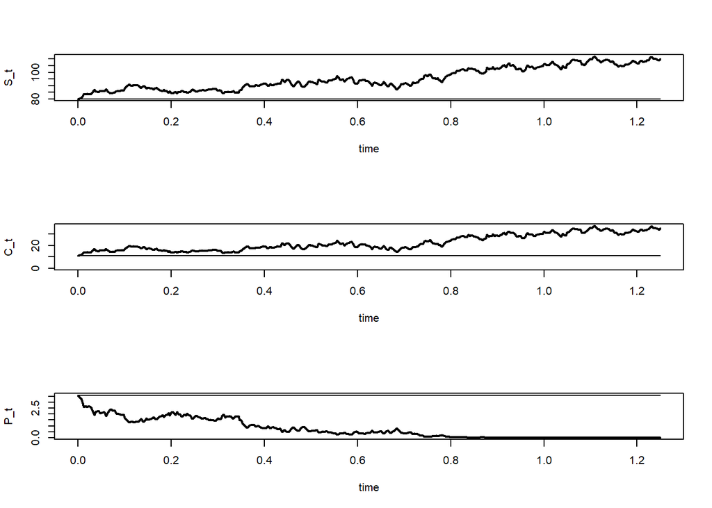

```r
#par(mfcol=c(3,1))
S_0=80;sigma=0.2;K=75;T=1.25;r=0.03;seed=8957
set.seed(seed)
t=(1:400)/400;t=t*T
z=rnorm(400,mean=0,sd=sigma*sqrt(T/400))
t=c(0,t)
z=c(0,z)
b=cumsum(z)
S_t=S_0*exp(b)
#plot(t,S_t,type="l",lwd=2,ylim=c(min(S_t),max(S_t)),xlab="time",ylab="S_t")
#lines(c(0,T),c(S_0,S_0))
C_t=BS_price_formula(S_t,sigma,K,T-t,r)
#plot(t,C_t,type="l",lwd=2,ylim=c(0,max(C_t)),xlab="time",ylab="C_t")
C=C_t[1]
#lines(c(0,T),c(C,C))
P_t=C_t+exp(-r*(T-t))*K-S_t
#plot(t,P_t,type="l",lwd=2,ylim=c(0,max(P_t)),xlab="time",ylab="P_t")
P=P_t[1]
#lines(c(0,T),c(P,P))
```

```r
S_t[length(S_t)]
C_t[length(C_t)]
P_t[length(P_t)]
```

When seed is $8957$:

- $S_t$ is 65.6063435.
- $C_t$ is 0.
- $P_t$ is 9.3936565.

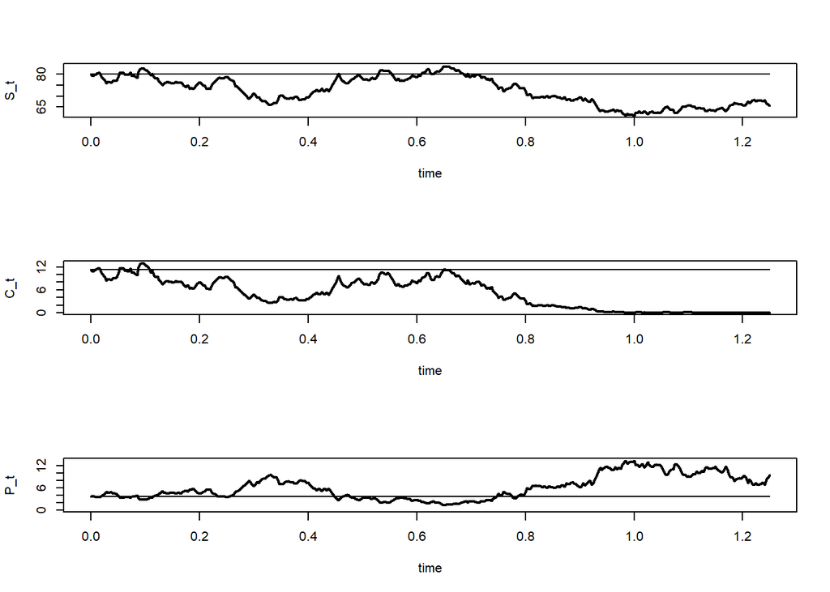

# Question 5

[24 points] Run lines 77 to 88 to define the function `delta()`. Run the function `delta()` for the case $S=80$, $T=1.25$, $t=0$, $K=75$, $\sigma=0.2$, and $r=0.03$. Submit the output.

```r
result=delta(S=80,T=1.25,t=0,K=75,sigma=0.2,r=0.03)
#result
```

- Call price ($\textbf{C}_t$) is $11.34635$
- Call delta ($\Delta_\textbf{C}$) is $0.71503$
- Put price ($\textbf{P}_t$) is $3.58594$
- Put delta ($\Delta_\textbf{P}$) is $-0.28497$

i) Report the price of the call option.

The price of the call option is 11.34635.

ii) Report delta for the call option.

The delta of the call option is 0.71503.

iii) Compute the leverage for the call option.

```r
0.71503*80/11.34635
```

```
## [1] 5.04148
```

$$\begin{align}
\text{call leverage}
&=\frac{\Delta_\textbf{C}\cdot S}{\textbf{C}_t}\\
&=\frac{0.71503\times80}{11.34635}\\
&=5.04148
\end{align}$$

iv) Compute the number of call options that would be purchased to replicate the change in price of $100$ shares of stock. How much would the options cost? How much would the shares cost?

```r
1/0.71503*100
```

```
## [1] 139.8543
```

$$\begin{align}
\text{number of call options}
&=\frac{1}{\Delta_\textbf{C}}\times\text{number of shares}\\
&=\frac{1}{0.71503}\times100\\
&=139.8543
\end{align}$$

```r
139.8543*11.34635
```

```
## [1] 1586.836
```

$$\begin{align}
\text{cost of call options}
&=\text{number of call options}\times\textbf{C}_t\\
&=139.8543\times11.34635\\
&=1586.836
\end{align}$$

$$\begin{align}
\text{cost of shares}
&=\text{number of shares}\times S\\
&=100\times80\\
&=8000\\
&=\text{cost of call options}\times\text{call leverage}\\
&=1586.836\times5.04148
\end{align}$$

v) Compute the number of call options that would be purchased to replicate the change in price of $\$250,000$ worth of stock. How much would the options cost?

$$\begin{align}
\text{number of call options}
&=\frac{1}{\Delta_\textbf{C}}\times\text{number of shares}\\
&=\frac{1}{\Delta_\textbf{C}}\times\frac{\text{cost of shares}}{S}\\
&=\frac{1}{0.71503}\times\frac{250000}{80}\\
&=4370.446
\end{align}$$

$$\begin{align}
\text{cost of call options}
&=\text{number of call options}\times\textbf{C}_t\\
&=4370.446\times11.34635\\
&=49588.61\\
&=\frac{\text{cost of shares}}{\text{call leverage}}\\
&=\frac{250000}{5.04148}
\end{align}$$

vi) Compute the number of put options that would be purchased to hedge the change in price of $100$ shares of stock. How much would the options cost? How much would the shares cost?

$$\begin{align}
\text{put leverage}
&=\frac{(\Delta_\textbf{P}-1)\cdot S}{\textbf{P}_t}\\
&=\frac{(-0.28497-1)\times80}{3.58594}\\
&=-28.66685
\end{align}$$

$$\begin{align}
\text{number of put options}
&=\frac{1}{\Delta_\textbf{P}}\times\text{number of shares}\\
&=\frac{1}{-0.28497}\times100\\
&=-350.9141
\end{align}$$

$$\begin{align}
\text{cost of put options}
&=\text{number of put options}\times\textbf{P}_t\\
&=-350.9141\times3.58594\\
&=-1258.357
\end{align}$$

$$\begin{align}
\text{cost of shares}
&=\text{number of shares}\times S\\
&=100\times80\\
&=8000
\end{align}$$

vii) Compute the number of put options that would be purchased to hedge the change in price of $\$250,000$ work of stock. How much would the options cost?

$$\begin{align}
\text{number of put options}
&=\frac{1}{\Delta_\textbf{P}}\times\text{number of shares}\\
&=\frac{1}{\Delta_\textbf{P}}\times\frac{\text{cost of shares}}{S}\\
&=\frac{1}{-0.28497}\times\frac{250000}{80}\\
&=-10966.07
\end{align}$$

$$\begin{align}
\text{cost of put options}
&=\text{number of put options}\times\textbf{P}_t\\
&=-10966.07\times3.58594\\
&=-39323.67
\end{align}$$